# On Ordering Fill Dirt for a Pentagonal Deck

[figure not shown]

I was recently given a real-world problem which required some interesting mathematics to solve:

> I remeasured the patio hole. Can you please use your math skills to estimate how much fill dirt I’m going to need? Cubic feet/yards… anything really. No hurry… just looking to price an estimate and see if it’s possible to do in one truck-load.

To give some context, my mother has been working on her yard recently and has kept me up to date on her DIY project of replacing her old wood patio with bricks. After pulling up the old wood, she found that there was a void under the patio that would need to be filled to begin tiling bricks at a height commensurate with the rest of her yard.

The first thing I thought of upon seeing this problem was Heron's formula: a triangle with sidelengths $a, b, c$ has area $A = \sqrt{s(s-a)(s-b)(s-c)}$ where $s = \frac{a + b +c}{2}$. In looking for a example for a generalization of this formula, I found an interesting paper on the area of cyclic $n$-gons (incribed in a circle) [here](https://rdcu.be/cn0AB), but I assumed it was too unlikely that all of these points would lie on a circle to make it worth checking if the condition held.

A little geometric thinking shows that no general formula can exist for a general $n$-gon with $n > 3$. Label two points, draw a line $\ell$ between them and circles $c_1,c_2$ of radii $r_1$ and $r_2$ centered at each point. If we pick a point $p \in c_1$, with a general point $q \in c_2$ a fixed distance $d$ from $p$, then we can find another point on $q' \in c_2$ of distance $d$ from $p$ through a mean value argument. One direction along $c_2$ from $q$ generally has shorter distance to $p$, but travel far enough in this direction and one ends up at the furthest point on $c_2$ from $p$, so there must be a point $q' \neq q$ on $c_2$ with the same distance from $p$, and one can easily see that each of these points provides a different area.

Perhaps making more assumptions will make this problem solvable? Having visited my mother before, I know that there is one right angle between the $10'$ and $12'$ sections. Fixing this angle at $(0,0)$, the $y$-axis the $12'$ length, and the $x$-axis the $10'$ length, we can construct circles of radius $6'6''$ and $7' 7''$ and look for the space of $12' 9''$ lengths between these circles. In the image below, we visualize the problem:

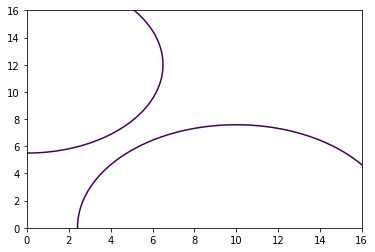

```python
import numpy as np
import matplotlib.pyplot as plt

b = 12
a = 10
A = 6 + 6/12
B = 12+ 9/12
C = 7 + 7/12

delta = 0.024
xrange =  np.arange(-5.0, 20.0, delta)
yrange =  np.arange(-5.0, 20.0, delta)
X, Y =  np.meshgrid(xrange,yrange)

C1 = (X-a)^2 + Y^2 -C^2
C2 = X^2+(Y-b)^2 - A^2

plt.contour(X, Y, C1, [0])
plt.contour(X, Y, C2, [0])
plt.axis([0,16,0,16])
plt.show()
```

We can solve this problem by finding coordinates $x,y,u,v$ considering the first circle to be $(y-b)^2 + x^2 -A^2 = 0$ and the second to be $ u^2+(v-a)^2 - C^2 = 0$ subject to the condition that the distance between any two points must be $B$, i.e. $(y-u)^2+ (x-v)^2 - B^2$. We let Sage create this ideal, and if all goes well we'll get the coordinates to drop right out of the Gröbner basis.

```python
R.<x,y,u,v> = PolynomialRing(QQ)
I = ideal((y-b)^2 + x^2 -A^2, u^2+(v-a)^2 - C^2, (y-u)^2+ (x-v)^2 - B^2)
```

```python
I.groebner_basis()
```

```
[x*y*v - y*v^2 - 134275/35136*x*y - 26855/5856*y^2 + 55225/17568*x*u - 11045/1464*x*v + 230905/17568*y*v - 4035/976*u*v + 2421/488*v^2 + 55225/1464*x + 919105/17568*y + 276125/8784*u - 12105/244*v - 42468025/210816, y^2*v + x*v^2 + 26855/5856*x*y - 134275/35136*y^2 - 11045/2928*x*u - 55225/8784*x*v …
```

All evidently did not go well, so let's check the dimension of the space satisfying our conditions.If the space is $0$-dimensional, then there's a finite set of solutions, and hopefully one of them will be the obvious right answer.

```python
I.dimension()
```

```
1
```

From this computation, we see there are infinitely many line configurations satisfying our conditions. If any two lead to unequal area, then we can use that the area is a polynomial in $x,y,u,v$ to invoke the intermediate value theorem giving us an infinite number of potential area values. Take $y = b, x = A$ and $v = a, u = C$ for a conveniant pair.

Once this was established, there was only one reply to send:

> No, but I can prove it!

That's the content of this post, but there was a happy ending. After explaining myself, I was able to solve her problem with a little trigonometry when given the information that another angle was right.

[figure not shown]

```python
# find the area of the triangle with three sidelengths
alpha = sqrt(a^2 + b^2)
beta = sqrt(C^2 + B^2)
#Heron's formula
s = (alpha + beta + A)/2
areathree = sqrt(s*(s-alpha)*(s-beta)*(s-A))
```

```python
# sum the area of the three triangles
pentareasqft = (a*b + B*C)/2 + areathree
# Find the volume in cubic feet
print(pentareasqft.n(40)*(8/12),pentareasqft.n(40)*(10/12))
# and in cubic yards
print(pentareasqft.n(40)*(8/(3*12)),pentareasqft.n(40)*(10/(3*12)))
```

```
104.22575245 130.28219056
34.741917484 43.427396855
```